# Influence of Parents Education Level on Childrens Schooling Performance

## by Daniel Stenberg

## Investigation Overview

Using the PISA study dataset from 2012, this investigation is focused on how the schooling performance of children is associated with the educational levels of their parents.

## Dataset Overview

The dataset that was used for this investigation consisted of the following variables:

- Nationality
- Educational levels of each parent (mother and father) as defined by the ISCED levels (0-6)
- PISA scores for math, reading and science

These variables were recorded for almost 500,000 students from 68 countries.

## Educational Levels of Mothers and Fathers

Let's start by taking a look at the ISCED levels of mothers and fathers of the PISA study children.

Note that:

- Level 5 is most common
- Level 0 is the second most common among fathers

The mean level of mothers is 3.16. The mean level of fathers is 3.05.

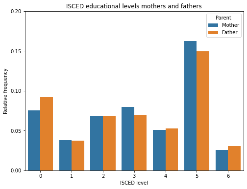

## Correlation to PISA scores - Mothers and Fathers Separate

In the plots below the relationship from mothers and fathers ISCED levels are respectively correlated with the mean PISA subject score.

In the plot, the median and quartiles are marked for each violin distribution diagram.

Some interesting things to note:

- PISA score generally increasing with parent ISCED levels
- There is a high variance, especially for parent ISCED level 6 (highest)
- Parents with lowest ISCED level (0) seem to correlate with slightly higher PISA score than level 1 parents

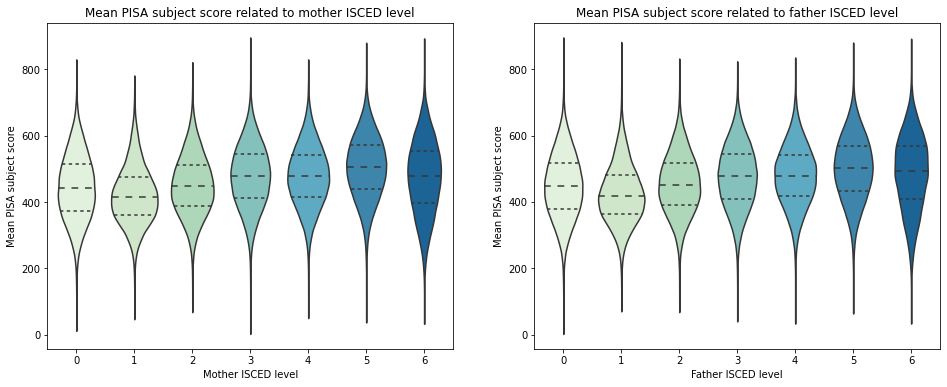

## Correlation to PISA scores - Mothers and Fathers Together

In the heat map below, ISCED levels of mothers and fathers are compared with mean PISA scores (subject average) in the same diagram, revealing some interesting findings:

- Some of the highest PISA scores are correlated with mother with ISCED level 5
- The lowest scores are correlated with one parent having a level 6 ISCED and the other at level 1
  - Especially visible for mother with level 1 ISCED

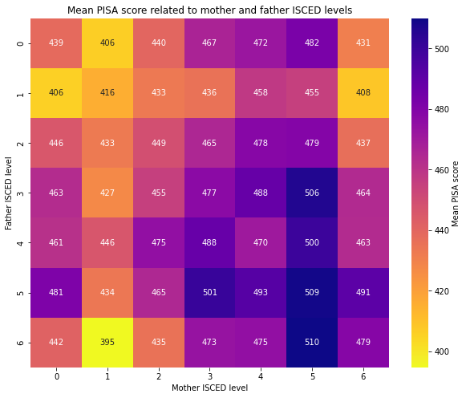